# A model of read counts and finding replicated regions

Ido Shalom, Daniel Rodan, Sagi Levin

2 July, 2024

### Libraries used

```r
# Load libraries
library("ggplot2")
library("data.table")
library("tictoc")
library("manipulate")
library(tidyverse)
library(fitdistrplus)
library(dplyr)
library(ggthemes)
library(scales)
library(gridExtra)
library(splines)
library(knitr)
```

### Paths and Data

```r
# Load the data for GC count
load(file = 'data/chr1_str_30M_50M.rda')

# Load the data for reads per cell
reads_file = 'data/raw/TCGA-13-0723-01A_lib1_all_chr1.forward'
```

```r
# Split letters
my_data = strsplit(chr1_str_30M_50M, '')[[1]][-1]

# Count bases in total
table(my_data)
```

```
## my_data
##       A       C       G       T
## 5487636 4541430 4517653 5453281
```

```r
# Load chromosome 1 reads
chr1_reads = fread(reads_file)

# Adding relevant columns names
colnames(chr1_reads) = c("Chrom","Loc","FragLen")

# Display summary
summary(chr1_reads)
```

```
##      Chrom        Loc               FragLen
##  Min.   :1   Min.   :       28   Min.   :-244390263
##  1st Qu.:1   1st Qu.: 43839514   1st Qu.:       144
##  Median :1   Median :108417844   Median :       155
##  Mean   :1   Mean   :116496437   Mean   :       846
##  3rd Qu.:1   3rd Qu.:186713491   3rd Qu.:       165
##  Max.   :1   Max.   :247199180   Max.   : 244920509
```

## Introduction

In this week’s task, we will implement the model we learned in class about how reads are distributed in a specific cell. with its help, we will try to find replicates of cells, taking into consideration the positive correlation between the CG content in a cell and the number of reads per cell.

## Setup

In preparation for this week’s task, we will first need to generate several items from our data:

- A function that counts the number of C+G bases per 5k cell.
- A function that calculates the number of reads per 5k cell.
- A function $f(gc_i)$, which is the expected value function dependent on the GC content in the cell (resulting from spline regression).

**Notes:**

- We chose a 5k cell size after trying different sizes, and this size best captures the decline in reads after the 0.6 CG content mark.
- We fitted the length and location of our segment from chromosome 1 for Lab 1 (30M - 50M) to be the exact part used in the reads file.
- For the $f(gc_i)$ function, we will use the “Completely Random Split” model for lab 5.

*The CG Count per cell function:*

```r
# Define the function to count C+G bases per cell
sum_CG_bases_in_cells <- function(genome, cell_size) {
  genome_length <- nchar(genome)

  # Initialize a vector to store the CG counts per cell
  CG_counts_per_cell <- numeric(ceiling(genome_length / cell_size))

  # Iterate over the genome by cell_size
  for (i in seq(1, genome_length, by = cell_size)) {
    end <- min(i + cell_size - 1, genome_length)
    cell <- substring(genome, i, end)

    # Count C and G bases in the cell
    CG_count <- sum(charToRaw(cell) == charToRaw("C")) + sum(charToRaw(cell) == charToRaw("G"))

    # Store the CG count in the vector
    CG_counts_per_cell[(i - 1) %/% cell_size + 1] <- CG_count
  }

  return(CG_counts_per_cell)
}


# Calculate CG counts per cell of size 5,000
CG_counts_5k <- sum_CG_bases_in_cells(chr1_str_30M_50M, 5000)
```

*The reads per cell function:*

```r
# Parameters definition
start_base <- 30000000
end_base <- 50000000
cell_size <- 5000

# Filter reads to the range of interest
reads_filtered <- chr1_reads[Loc >= start_base & Loc <= end_base]

# Function to calculate the number of reads per cell
calculateReadsPerCell <- function(reads, cell_size, start_base, end_base) {
  num_cells <- ceiling((end_base - start_base + 1) / cell_size)
  reads_per_cell <- integer(num_cells)

  for (i in seq_len(num_cells)) {
    cell_start <- start_base + (i - 1) * cell_size
    cell_end <- min(cell_start + cell_size - 1, end_base)
    reads_per_cell[i] <- sum(reads$Loc >= cell_start & reads$Loc <= cell_end)
  }

  return(reads_per_cell)
}

# Calculate the coverage per cell
reads_cell_5k <- calculateReadsPerCell(reads_filtered, cell_size, start_base, end_base)
```

*The $f(gc_i)$ function*

```r
# Define the knots
knots <- c(0.36, 0.43, 0.50, 0.57)

# CG content
if (any(CG_counts_5k > 1)) {
  CG_counts_5k <- CG_counts_5k / 5000
}

# Filter the data
filtered_index <- (reads_cell_5k <= 500) & (CG_counts_5k >= 0.29) & (CG_counts_5k<= 0.64)
GC_content_filtered <- CG_counts_5k[filtered_index]
reads_filtered <- reads_cell_5k[filtered_index]


# Set seed
set.seed(245)

# Using method 2 from Lab 5
random_sample_2 <- sample(length(GC_content_filtered), size = 0.7 * length(GC_content_filtered))

train_index_2 <- rep(FALSE, length(GC_content_filtered))
train_index_2[random_sample_2] <- TRUE
test_index_2 <- !train_index_2

# Train and test sets
train_set_2 <- data.frame(GC_content = GC_content_filtered[train_index_2], Reads = reads_filtered[train_index_2])


# Fit the cubic spline regression model
f <- lm(Reads ~ bs(GC_content, knots = knots), data = train_set_2)
```

## Part A: Function that estimates genomic copy number

like we learned in class, the operation of the function is that, for each observed reads cell value Y[i], it calculates an estimate a[i] for the copies number, dividing Y[i] by the predicted value f_gc[i] from the model.

```r
# Function to estimate genomic copy number
estimate_copy_number <- function(Y, GC, f_model) {

  # Calculate f(gc_i)
  f_gc <- predict(f,newdata = data.frame(GC_content = GC))

  # Initialize vector to store the estimates for a
  a_estimates <- numeric(length(Y))

  # Iterate over the observed coverage values to estimate a_i
  for (i in seq_along(Y)) {
    a_estimates[i] <- Y[i] / f_gc[i]
  }
  return(a_estimates)
}
```

## Part B: Opration of the function for a spcific cell segment

### Question 1: Estimates histogram & distribution along the chromosome

We took a continuous cell region that is between 1000 to 1999. This means from the 35M location on the chromosome to the 40M location. We created a histogram where each bin represents 20 cells, and the density is the multiple of the cells.

For example, there are 90 cells (20 * 4.5) with an “a” value just above 1 (the first column after 1).

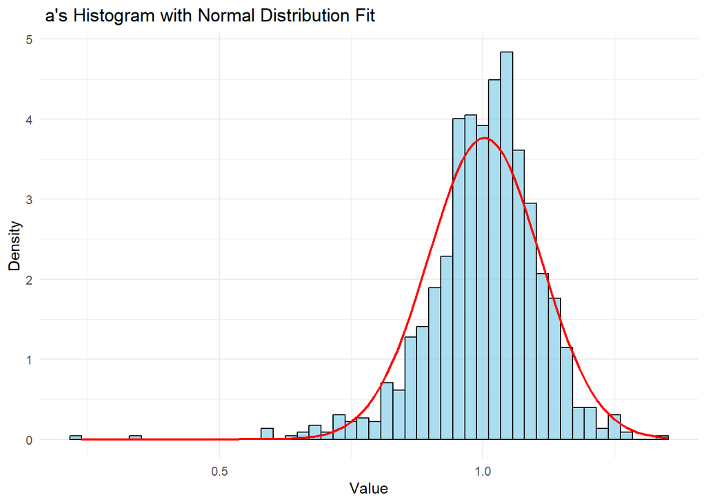

```r
# "a" estimate in the wanted range
all_a_hat <- estimate_copy_number(reads_filtered[1000:1999], GC_content_filtered[1000:1999], f)

# Convert all_a_hat to a data frame
all_a_hat_df <- data.frame(value = all_a_hat)

# Create the histogram
p <- ggplot(all_a_hat_df, aes(x = value)) +
  geom_histogram(aes(y = ..density..), bins = 50, fill = "skyblue", color = "black", alpha = 0.7) +
  stat_function(fun = dnorm, args = list(mean = mean(all_a_hat), sd = sd(all_a_hat)),
                color = "red", size = 0.75) +
  labs(title = " a's Histogram with Normal Distribution Fit",
       x = "Value",
       y = "Density") +
  theme_minimal()

# Display the plot
print(p)
```

**Results Explanations:**

The results might contradict what we expected. In theory, we would expect that after handling the CG content correlations, we would get a much higher concentration of cells around the value 1, as it represents 1 copy per cell.

In reality, we obtained a somewhat close to normal distribution with a mean around 1. We believe there is a lot more noise than we would expect, indicating that factors other than just the CG content may affect the number of reads per cell.

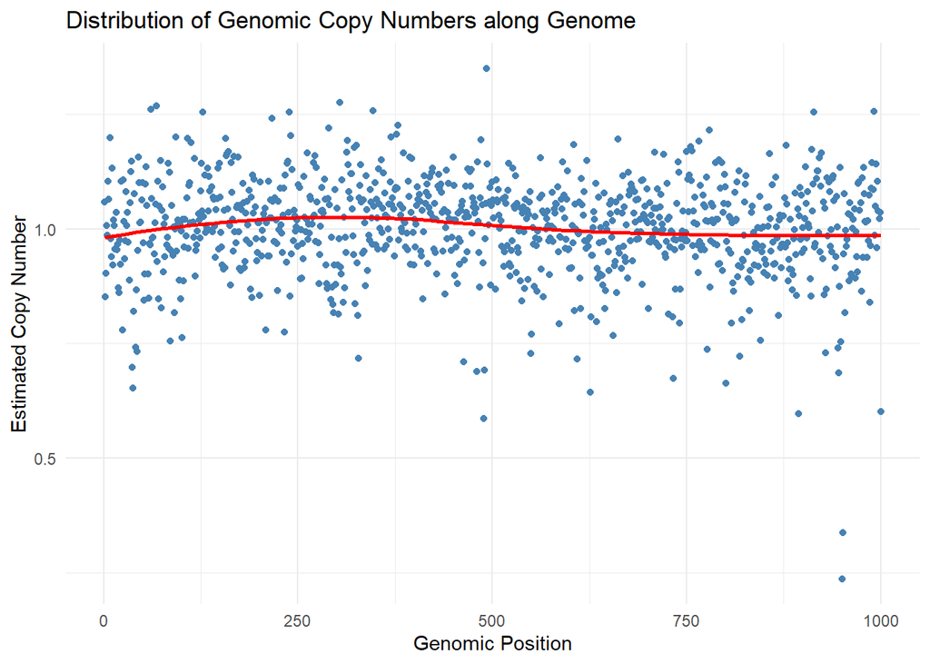

```r
# Subset the data for the 1000 consecutive cells
subset_reads <- reads_filtered[1000:1999]
subset_GC <- GC_content_filtered[1000:1999]

# Estimate genomic copy numbers
genomic_copy_estimates <- estimate_copy_number(subset_reads, subset_GC, f)

# location normalized
genome_positions <- 1:1000

copy_number_data <- data.frame(Genome_Position = genome_positions, Copy_Number = genomic_copy_estimates)

# distribution along the genome
plot_genome_distribution <- ggplot(copy_number_data, aes(x = Genome_Position, y = Copy_Number)) +
  geom_point(color = "steelblue") +  # Scatter plot of copy number estimates
  geom_smooth(formula = y ~ x,method = "loess", se = FALSE, color = "red") +  # Smoothed line for trend
  labs(title = "Distribution of Genomic Copy Numbers along Genome",
       x = "Genomic Position",
       y = "Estimated Copy Number") +
  theme_minimal()

# Print the plot
print(plot_genome_distribution)
```

**Results Explanations:**

One reason that we could check why we got the histogram of “a” as we did, is that there might be another effect where different locations of cells bring out significantly different values of the “a” estimate.

From the plot we obtained for our specific case, we are not quite sure that this is true. We do see that we did not get a horizontal straight line at the value 1, but we don’t think it is significant enough to assume that the location matters when we look at the “a” estimate value.

### Question 2: Quantitative measure $MAD$

As a quantitative measure, we chose the $MAD$ - mean absolute deviation.

What it does is take the “a” estimates we got, subtract 1 from each, and then take the absolute value (because we don’t care in which direction it deviates from 1 right now, just that it is far from 1).

```r
# Compute absolute deviations from the target value (1)
absolute_deviations <- abs(genomic_copy_estimates - 1)

# Calculate the MAD
mean_absolute_deviation <- mean(absolute_deviations)

# Print the result
mean_absolute_deviation
```

```
## [1] 0.07832484
```

**Results Explanations:**

We got $MAD$ of approximately 0.0783, which indicates that, on average, the estimated genomic copy numbers deviate by this amount from the target value of 1.

The problem we have with the $MAD$ is that the number we get, don’t tells us much about what is its magnitude - what does it mean in terms of copies that “$MAD$ of approximately 0.0783”?

## Part C: Evaluation of the copy estimates

Overall, we believe that the “a” values do a good job of estimating the number of copies per cell.

However, we can think of reasons why it might not be the best estimator.

First, there may be a dependency on the locations concerning the number of copies. We previously claimed it might not be significant in our analysis, but to be absolutely sure, we would need to check a much larger range of the chromosome.

Second, we don’t know the magnitude of the variance in the noise factor (V value). We assumed that it is relatively low and has little to no impact, so we ignored it when computing “a”. However, this is not necessarily true, and if we encounter a large V value, it could significantly affect the accuracy of the copy number estimator “a”.

## Part D: Idea to estimate “V”

We thought that because we used the method of moments to compute the “a” values, it makes sense to use the method of moments to compute the “V” value.

Let’s show it in a code:

```r
# Define the Method of Moments estimator for v
method_of_moments_v <- function(Y, GC, f_model) {
  lambda <- estimate_copy_number(Y, GC, f_model)
  eta <- lambda / Y
  v_estimate <- var(eta)
  return(v_estimate)
}

# Our filtered  data
Y <- reads_filtered[1000:1999]
GC <- GC_content_filtered[1000:1999]

# Estimate v using Method of Moments
estimated_v <- method_of_moments_v(Y, GC, f)

# Print the estimated value of v
sprintf("%.10f", estimated_v)
```

```
## [1] "0.0000006698"
```

**Results Explanations:**

The estimator being very close to 0 (e.g., 6.697984×10−7) suggests that our assumption of a low V value and a normal distribution of noise with a mean of 1 could be reasonable.

If that the case then, the noise for the $\lambda$ value, does not have much impact on it.

This emphasizes that there may be another reason for the deviation from 1 in the “a” estimate, which might give us the real reason why we see different amounts of copies in some cells.

## Short summary

So it is safe to say that taking into consideration the correlations of GC content with the number of reads per cell, and only then computing an estimate for the number of copies per cell, showed pretty good results.